# Projekt analizy danych z Udemy

Author

Artur Kidaj, Kamil Kopiński

## Przedstawienie danych

Zbiór danych przedstawia szeroki zakres informacji dotyczących kursów oferowanych przez platformę e-learningową Udemy. Zawiera on dane takie jak tytuł kursu, jego cenę, liczbę subskrybentów, poziom trudności, datę i godzinę publikacji, jak również główną tematykę każdego kursu. Dzięki temu zapewnia kompleksowy przegląd oferty edukacyjnej dostępnej na Udemy, umożliwiając analizę zarówno poszczególnych kursów, jak i ogólnych trendów w zakresie edukacji online.

Udemy to masowa platforma kursów online (MOOC), która oferuje zarówno darmowe, jak i płatne kursy. Każdy może stworzyć kurs, co jest modelem biznesowym, który pozwolił Udemy na posiadanie setek tysięcy kursów.

Oto pierwsze pięć wierszy z tabeli.

| course_title | is_paid | price | num_subscribers | num_reviews | num_lectures | level | content_duration | published_timestamp | subject |
| --- | --- | --- | --- | --- | --- | --- | --- | --- | --- |
| Learn HTML5 Programming From Scratch | False | 0 | 268923 | 8629 | 45 | All Levels | 10.5 | 2013-02-14T07:03:41Z | Web Development |
| Coding for Entrepreneurs Basic | False | 0 | 161029 | 279 | 27 | Beginner Level | 3.5 | 2013-06-09T15:51:55Z | Web Development |
| The Web Developer Bootcamp | True | 200 | 121584 | 27445 | 342 | All Levels | 43.0 | 2015-11-02T21:13:27Z | Web Development |
| Build Your First Website in 1 Week with HTML5 and CSS3 | False | 0 | 120291 | 5924 | 30 | Beginner Level | 3.0 | 2014-04-08T16:21:30Z | Web Development |
| The Complete Web Developer Course 2.0 | True | 200 | 114512 | 22412 | 304 | All Levels | 30.5 | 2016-03-08T22:28:36Z | Web Development |

Dane zawierają *3678* obserwacji podzielonych na *10* zmiennych.

### Zmienne

- `course_title` - Tytuł kursu.
- `is_paid` - Informuje o tym, czy dany kurs jest płatny.
- `price` - Ukazuje cenę kursu wyrażoną w dolarach.
- `num_subscribers` - Ukazuje liczbę subskrybentów kursu.
- `num_reviews` - Ukazuje liczbę recenzji kursu.
- `num_lectures` - Ukazuje liczbę wykładów kursu.
- `level` - Przedstawia poziom trudności kursu podzielną na cztery kategorie:
  - *`Beginner Level`* - poziom początkujący.
  - *`Intermediate Level`* - poziom średniozaawansowany.
  - *`Expert Level`* - poziom zaawansowany.
  - *`All levels`* - wszystkie poziomy.
- `content_duration` - Ukazuje długość kursu wyrażoną w godzinach.
- `published_timestamp` - Przedstawia datę publikacji kursu o następującej strukturze: *rok-miesiąc-dzień T - godzina:minuta:sekunda Z*
- `subject` - Przedstawia temat kursu wyrażonego w czterech różnych kategoriach:
  - *`Business Finance`* - finanse
  - *`Graphic Design`* -projekt graficzny.
  - *`Musical Instruments`* - muzyczne instrumenty.
  - *`Web Development`* - tworzenie stron internetowych.

### Cele badawcze

1. **Analiza Trendów Rozwojowych Platformy Udemy**: Celem jest przeprowadzenie szczegółowej analizy historycznych danych, aby zidentyfikować trendy w rozwoju platformy, w tym wzrost liczby użytkowników, ceny kursów oraz ich rozkład tematyczny. Szczególny nacisk zostanie położony na wizualizację danych, umożliwiającą łatwe zrozumienie zmian zachodzących w czasie
2. **Badanie Korelacji i Zależności między Zmiennymi Charakteryzującymi Kursy**: Przedmiotem analizy będą wzajemne zależności między różnymi atrybutami kursów, takimi jak cena, liczba uczestników, recenzji oraz długość kursów. Celem jest zrozumienie, jak te czynniki wzajemnie na siebie wpływają i w jakim stopniu mogą determinować popularność kursu.
3. **Modelowanie Prognozujące Rozwój Nowych Kursów**: Celem jest zbudowanie modeli statystycznych i predykcyjnych, które pozwolą ocenić potencjalną popularność i sukces nowo wprowadzanych kursów na platformie. Modele będą oparte na analizie historycznych danych o kursach i ich wynikach, a także mogą uwzględniać zewnętrzne wskaźniki rynkowe i trendy edukacyjne.

### Czyszczenie i przygotowanie danych

Analiza w poszukiwaniu brakujących wartości wykazała, że w badanym zbiorze danych nie występują luki informacyjne. Kolejnym etapem było zbadanie zbioru pod kątem występowania powtarzających się wierszy. Stwierdzono obecność 6 duplikatów, które zostały usunięte w celu zapewnienia większej precyzji i wiarygodności przyszłych analiz.

W celu usprawnienia procesu przetwarzania i analizy danych, podjęto decyzję o dokonaniu istotnych zmian w strukturze danych. Atrybuty `level`, `is_paid` oraz `subject` zostały przekonwertowane na zmienne typu factor, co pozwoli na bardziej efektywne wykorzystanie pamięci i przyspieszenie analiz. Dodatkowo, zmienna `published_timestamp` została dostosowana poprzez ograniczenie jej zawartości do roku, miesiąca i dnia, a następnie przekształcenie w format daty. Te zmiany mają kluczowe znaczenie dla zwiększenia wydajności przyszłych analiz danych.

### Analiza eksploracyjna

Podstawowe statystyki

| variable | min | q1 | median | mean | q3 | max |
| --- | --- | --- | --- | --- | --- | --- |
| price | 0 | 20.00 | 45 | 66.103 | 95.00 | 200.0 |
| num_subscribers | 0 | 111.75 | 912 | 3190.587 | 2548.75 | 268923.0 |
| num_reviews | 0 | 4.00 | 18 | 156.371 | 67.00 | 27445.0 |
| num_lectures | 0 | 15.00 | 25 | 40.140 | 46.00 | 779.0 |
| content_duration | 0 | 1.00 | 2 | 4.098 | 4.50 | 78.5 |

## Wizualizacja danych

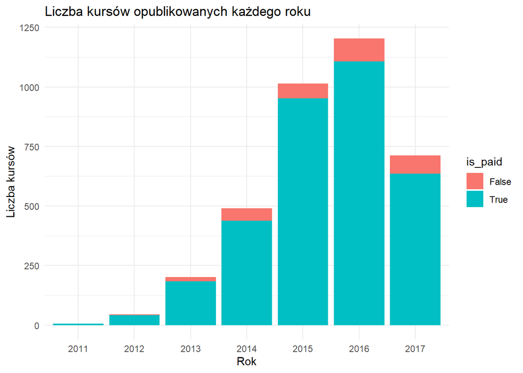

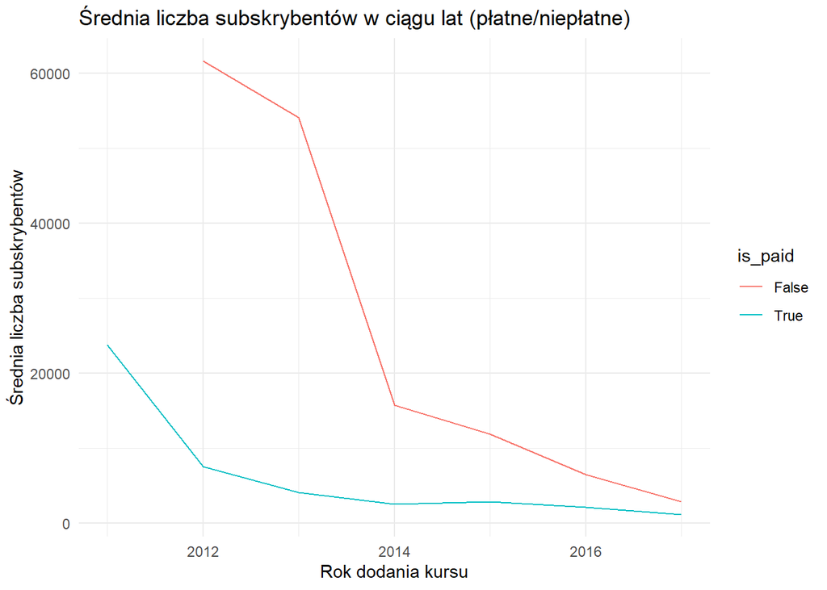

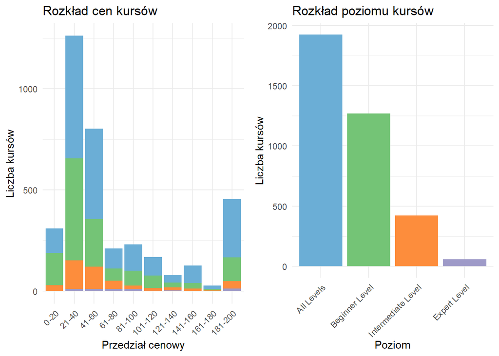

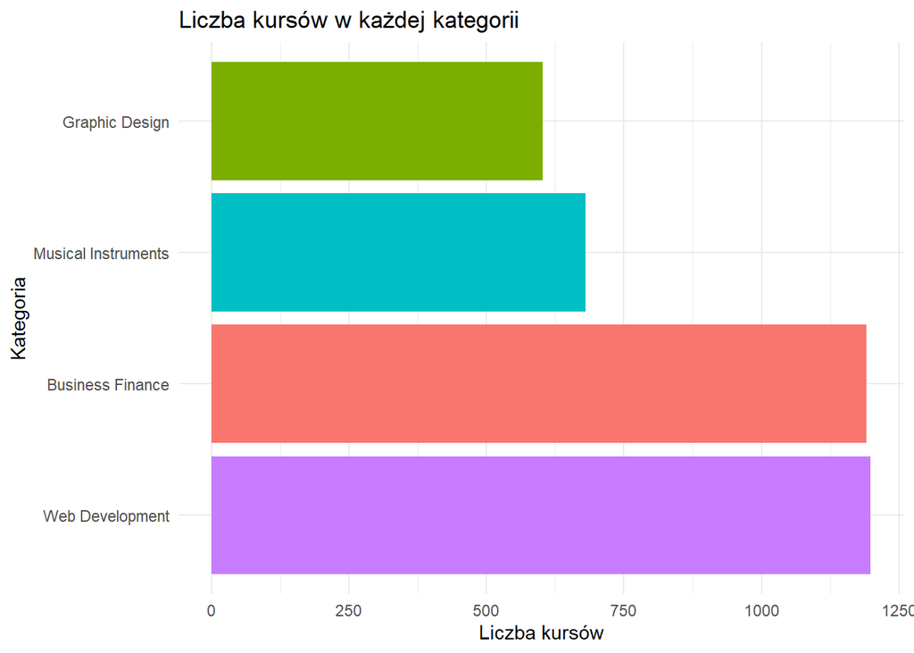

Wysoka liczba kursów w kategoriach “Finanse Biznesowe” i “Rozwój Stron Internetowych” może wskazywać na znaczny popyt na edukację w tych obszarach. Może to być związane z rosnącą potrzebą kompetencji w dziedzinie finansów i technologii, co jest istotne w obecnym krajobrazie ekonomicznym i zawodowym.Rozwój rynku pracy może preferować umiejętności związane z IT i biznesem, co tłumaczyłoby większą dostępność kursów w tych dziedzinach.

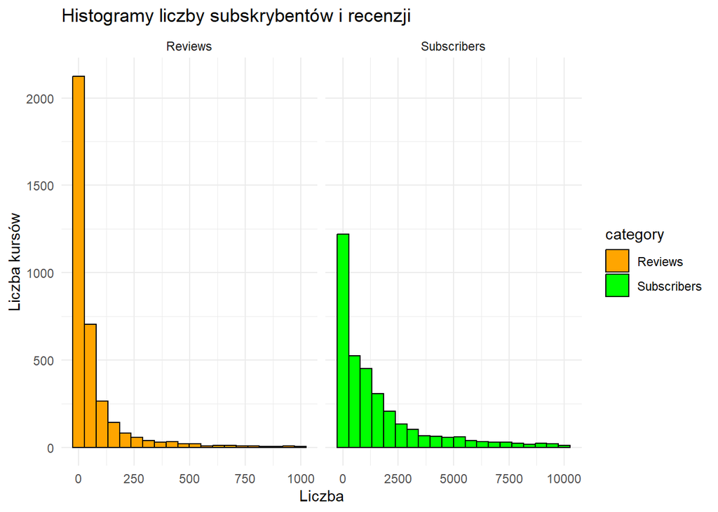

Analiza histogramów recenzji i subskrybentów wskazuje na silnie skośny rozkład w obu przypadkach, z dominacją kursów o niewielkiej liczbie recenzji oraz subskrybentów. Większość kursów ma mniej niż 250 recenzji i mniej niż 2500 subskrybentów, co może świadczyć o ich nowości lub ograniczonej popularności. Wysoka skośność w obu dystrybucjach wskazuje na obecność niewielkiej liczby kursów o wyjątkowo wysokiej liczbie recenzji i subskrybentów, co sugeruje zdominowanie rynku przez kilka bardzo popularnych kursów. Te dane mogą dostarczyć cennych wskazówek twórcom kursów na temat obecnego stanu rynku i możliwości rozwoju ich oferty.

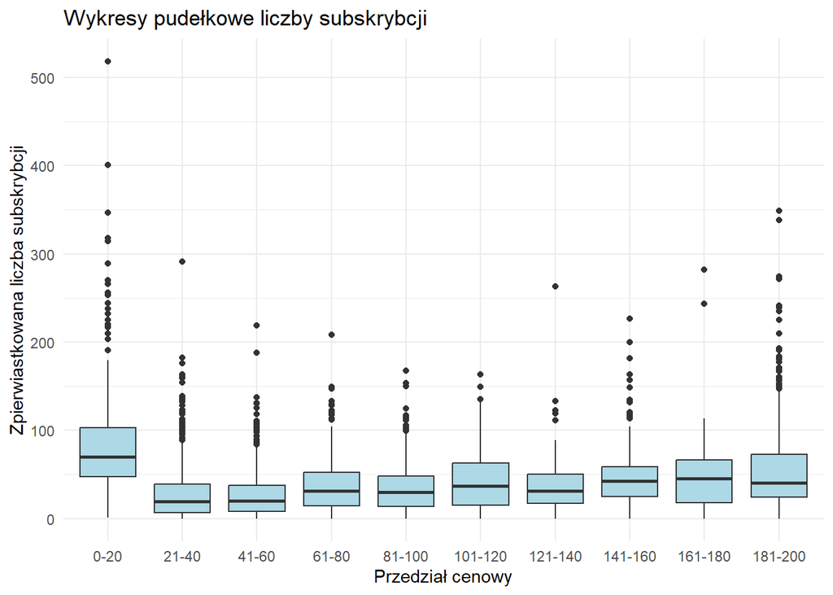

Wykres prezentuje rozrzut liczby subskrypcji dla różnych przedziałów cenowych. Wartość liczby subskrypcji została poddana pierwiastkowaniu w celu lepszej wizualizacji wykresu. W trakcie analizy należy pamiętać zatem, że wszelkie różnice na wykresie oryginalnym byłyby większe.

W przedziale cenowym 0-20 widoczne jest, że zarówno mediana jak i kwartyle znajdują się znacznie wyżej niż dla pozostałych kategorii. W kolejnym przedziale można zaobserwować drastyczny spadek wysokości rozrzutu, a następnie uwydatnia się trend wzrostowy. Sytuacja to może odzwierciedlać to, że najpopularniejszymi kursami są te darmowe, jednak gdy już użytkownik zdecydował się zapłacić za kurs to częściej wybiera droższy.

### Macierz korelacji

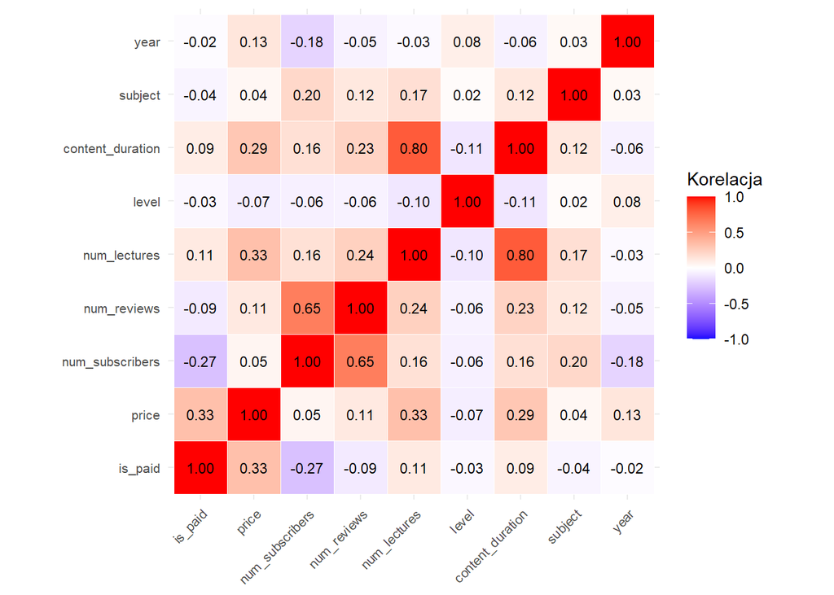

Analiza wykazała słabą negatywną korelację między płatnością kursu a liczbą subskrybentów, co sugeruje, że kursy darmowe mają tendencję do przyciągania większej liczby uczniów. Nie stwierdzono silnej korelacji między długością kursu a jego poziomem trudności. Istnieje natomiast silna korelacja między liczbą recenzji a liczbą subskrybentów, co wskazuje, że popularniejsze kursy otrzymują więcej recenzji. Znaczna korelacja została również zauważona między liczbą wykładów a czasem trwania treści kursu. Poziom trudności kursu nie wykazuje silnej korelacji z innymi zmiennymi, co może wskazywać, że jest ustalany niezależnie od innych aspektów kursu. Ogólnie, wyniki sugerują, że niektóre cechy kursów są ściśle powiązane, podczas gdy inne, takie jak poziom trudności, nie mają znaczącego wpływu na mierzone atrybuty.

### Miary asymetrii i koncentracji

|  | price | num_subscribers | num_reviews | num_lectures | content_duration |
| --- | --- | --- | --- | --- | --- |
| skewness | 1.157 | 11.596 | 17.797 | 4.868 | 5.423 |
| kurtosis | 3.090 | 226.694 | 401.001 | 39.693 | 45.976 |

Analiza miar koncentracji wykazała że rozkład cen jest mezokurtyczny - jednostki koncentrują się tak jak w rozkładzie normalnym - natomiast rozkład pozostałych zmiennych jest leptokurtyczny - jednostki koncentrują się przy średniej arytmetycznej silniej niż w przypadku rozkładu normalnego. Miary osiągają wartość dwucyfrową dla długości kursu iliczny wykładów, oraz wartość trzycyfrową dla liczby subskrypcji i liczby recenzji.

Zatem na podstawie powyższych wyników możemy przypuszczać, że żadna ze zmiennych nie posiada rozkładu normalnego.

## Modelowanie danych

### Regresja liniowa

Zanim przystąpimy do zbudowania modelu liniowego należy wybrać dane do analizy. W przypadku zmiennej objaśnianej jest to zmienna `num_subscribers`. Natomiast w przypadku zmiennych objaśniających narzuca się to, że `contetn_duration` oraz `num_lectures` są ze sobą mocno skorelowane, zatem nie powinny być ze sobą w jednym modelu. Ciężko jest jednak stwierdzić, którą z nich należy umieścić. By temu zaradzić, a zarazem sprawdzić pozostałe zmienne skorzystamy z pomocy regresji krokowej.

Selekcja w przód

```
lm(formula = num_subscribers ~ num_reviews + year + is_paid +
    subject + price + level - 1, data = df)
```

Eliminacja wsteczna

```
lm(formula = num_subscribers ~ num_reviews + price + level +
    subject + year + is_paid, data = df)
```

Korzystając z dwóch kierunków regresji krokowej otrzymaliśmy modele różniące się tylko zwartością wyrazu wolnego. Przez funkcję odrzucone zostały zarówno zmienne `content_duration` jak i `num_lectures`.

Zatem model składa się ze zmiennej zależnej `num_subscribers` oraz zmiennych niezależnych: `num_reviews`, `price`, `subject`,`level`,`year` oraz `is_paid` .

#### Obserwacje nietypowe

Pozbędziemy się teraz obserwacji nietypowych.

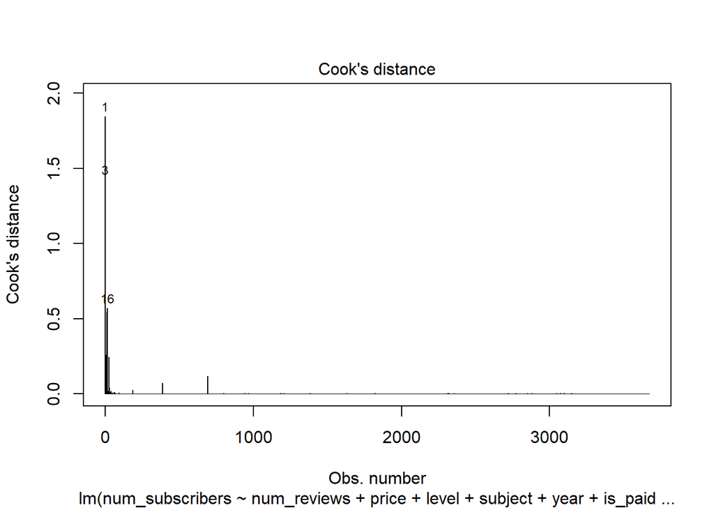

```
        1         3        12        16
1.8469867 1.4254800 0.5413482 0.5712604
```

Na podstawie wyżej ukazanych wykresów oraz wartości odległości cook’a możemy stwierdzić, że w modelu znajdują się obserwacje nietypowe. Są to obserwacje numer 1,3,12oraz 16.

Jednak nie zamierzamy ich usuwać.

#### Interakcje

W naszym modelu liniowym znajdują się zmienne jakościowe, co może powodować wytworzeniem się interakcji między zmiennymi. Z uwagi na dużą liczbę możliwych obserwacji ograniczymy się jedynie do jednej. Przeanalizujmy zatem, czy istnieje interakcja pomiędzy zmienną ilościową `price` a zmienną jakościową `subject`.

Dzięki temu, że model bez interakcji jest zagnieżdżony w modelu z interakcją możemy wykorzystać do ich porównania Częściowy Test F.

```
Analysis of Variance Table

Model 1: num_subscribers ~ num_reviews + price + level + subject + year +
    is_paid
Model 2: num_subscribers ~ num_reviews + price + level + subject + year +
    is_paid + price:subject
  Res.Df        RSS Df Sum of Sq      F   Pr(>F)
1   3656 1.5587e+11
2   3653 1.5526e+11  3 611796851 4.7981 0.002445 **
---
Signif. codes:  0 '***' 0.001 '**' 0.01 '*' 0.05 '.' 0.1 ' ' 1
```

Na podstawie wyniku Częściowego Testu F - p.value <0.05 - możemy stwierdzić, że model bardziej złożony jest lepszy od prostszego. Oznacza to, że w modelu występuje interakcja pomiędzy zmiennymi `pirce` oraz `subject`. Niewiadomo jednak dokładnie które poziomy posiadają interakcje. Przeanalizujemy to podczas analizy modelu.

#### Model

Ostatecznie otrzymujemy model:

```
Call:
lm(formula = num_subscribers ~ num_reviews + price + level +
    subject + year + is_paid + price:subject, data = df)

Residuals:
   Min     1Q Median     3Q    Max
-48626  -1869   -282    961 200477

Coefficients:
                                   Estimate Std. Error t value Pr(>|t|)
(Intercept)                       2.258e+04  2.965e+03   7.616 3.32e-14 ***
num_reviews                       6.057e+00  1.188e-01  50.983  < 2e-16 ***
price                             1.244e+01  3.021e+00   4.119 3.90e-05 ***
levelBeginner Level               3.037e+02  2.420e+02   1.255 0.209522
levelIntermediate Level          -6.260e+02  3.543e+02  -1.767 0.077335 .
levelExpert Level                -1.159e+03  8.743e+02  -1.326 0.184944
subjectGraphic Design             3.660e+02  4.709e+02   0.777 0.437003
subjectMusical Instruments       -3.050e+02  4.813e+02  -0.634 0.526313
subjectWeb Development            3.841e+03  4.040e+02   9.508  < 2e-16 ***
year2012                         -6.760e+03  3.078e+03  -2.197 0.028108 *
year2013                         -1.025e+04  2.960e+03  -3.462 0.000542 ***
year2014                         -1.436e+04  2.939e+03  -4.887 1.07e-06 ***
year2015                         -1.517e+04  2.929e+03  -5.179 2.35e-07 ***
year2016                         -1.620e+04  2.929e+03  -5.530 3.43e-08 ***
year2017                         -1.672e+04  2.935e+03  -5.697 1.31e-08 ***
is_paidTrue                      -7.618e+03  4.217e+02 -18.067  < 2e-16 ***
price:subjectGraphic Design       5.335e+00  5.500e+00   0.970 0.332203
price:subjectMusical Instruments  7.349e+00  6.759e+00   1.087 0.276957
price:subjectWeb Development     -1.077e+01  4.123e+00  -2.612 0.009033 **
---
Signif. codes:  0 '***' 0.001 '**' 0.01 '*' 0.05 '.' 0.1 ' ' 1

Residual standard error: 6519 on 3653 degrees of freedom
Multiple R-squared:  0.5302,    Adjusted R-squared:  0.5279
F-statistic:   229 on 18 and 3653 DF,  p-value: < 2.2e-16
```

Na podstawie otrzymanej statystyki testu F której p.value <0.05 możemy stwierdzić, że model jest istotny statystycznie.

Rozrzut błędu nie jest równomierny zatem możemy przypuszczać, że rozkład modelu nie jest rozkładem normalnym.

Analiza:

- `Intercept` jest istotny statystycznie, posiada współczynnik równy 22583.99. Interpretacja wyrazu wolnego nie ma jednak sensu, gdyż wychodziłoby, że bezpłatny kurs z 2011 bez żadnych recenzji o tematyce finansowej i przeznaczonej dla wszystkich osiąga ponad dwadzieścia tysięcy subskrypcji.
- `num_reviews` jest istotny statystycznie, posiada współczynnik równy 6.05, zatem każda dodatkowa recenzja powoduje zwiększenie liczby subskrypcji średnio o 6.05, przy założeniu, że pozostałe zmienne będą takie same.
- `pirce` jest istotny statystycznie, posiada współczynnik równy 12.44, zatem jeżeli kurs jest droższy o jednego dolara to statystycznie będzie mieć o średnio 12.44 więcej subskrypcji, przy założeniu, że pozostałe zmienne będą takie same.
- `level`:
  - `All Levels` jest poziomem bazowym
  - Pozostałe poziomy nie są istotne statystycznie. Oznacza to że wszystkie poziomu trudności kursu są popularne na podobnym poziomie.
- `subject`:
  - `Business Finance` jest poziomem bazowym
  - poziom `Web development` jest istotny statystycznie, jego współczynnik wynosi 3840.72, zatem kurs o temacie rozwoju stron średnio otrzyma o 3840.72 subskrypcji więcej niż kurs o biznesie, jeżeli pozostałe zmienne pozostaną takie same.
  - pozostałe poziomy nie są istotne statystycznie. Zatem tematy nie różnią się od biznesu w kontekście popularności.
- `year`:
  - `2011` jest poziomem bazowym
  - Wszystkie pozostałe poziomy są istotne statystycznie, posiadają ujemne współczynniki, oznacza to że kursy powstałe w 2011 były przeciętnie dużo popularniejsze od później powstałych.
- `is_paid`:
  - `False` jest poziomem bazowym
  - poziom `True` jest istotny statystycznie, posada współczynnik równy -7618.18. Oznacza to, że statystycznie kursy darmowe uzyskują dużo więcej subskrypcji od płatnych.
- Interakcje:
  - Występuje interakcja pomiędzy zmienną `price` a poziomem `Web development`, posiada współczynnik równy -10.77, co oznacza że w przypadku kursów o tematyce rozwoju storn internetowych to tańsze kury były bardziej popularne.

Ocena dopasowanie modelu:

- RMSE = 6502.53
- R.squared = 0.53
- MAE = 2624.01

#### Podstawowe założenia

Sprawdźmy podstawowe założenia modelu.

|  | Test | P.wartość |
| --- | --- | --- |
| Liniowość | Reset | 6.486080e-64 |
|  | Rainbow | 0.000000e+00 |
| Homoskedastyczność | Breusch-Pagan | 2.182194e-51 |
| Autokorelacja | Durbin-Watson | 2.123590e-148 |
| Normalność | Lillie | 0.000000e+00 |
|  | Shapiro-Wilk | 2.393856e-75 |
|  | Cramer-Von-Mises | 7.370000e-10 |
|  | Anderson-Darling | 3.700000e-24 |

Żadne założenie nie zostało spełnione, zatem Twierdzenie Gaussa-Markowa nie jest spełnione.Model nie jest użyteczny, zatem poprzednio wypisane wnioski nie muszą odzwierciedlać stanu faktycznego.

### PCA

Spróbujemy zatem utworzyć model regresji liniowej przy pomocy metody analizy głównych składowych. Do stworzenia modelu nie możemy użyć zmiennych jakościowych, zatem ograniczamy się do zmiennych ilościowych. Wybieramy użyte już wcześniej `num_reviews` i `price` oraz jedną z dwóch skorelowanych zmiennych `num_lectures` lub `content_duration`. Decydujemy się na `num_lectures`

```
                   PC1         PC2        PC3
price        0.5795463 -0.57010203 -0.5823313
num_reviews  0.4813783  0.81606859 -0.3198546
num_lectures 0.6575720 -0.09495117  0.7473843
```

Powstały model składa się z 3 składowych :

$$\begin{align}
PC1 = 0.58 \cdot \text{price} + 0.48 \cdot \text{num\_reviews} + 0.66 \cdot \text{num\_lectures} \\\\
PC2 = -0.57 \cdot \text{price} + 0.82 \cdot \text{num\_reviews} - 0.09 \cdot \text{num\_lectures} \\\\
PC3 = -0.58 \cdot \text{price} - 0.32 \cdot \text{num\_reviews} + 0.75 \cdot \text{num\_lectures}
\end{align}$$

```
Importance of components:
                          PC1    PC2    PC3
Standard deviation     1.2119 0.9447 0.7993
Proportion of Variance 0.4896 0.2975 0.2130
Cumulative Proportion  0.4896 0.7870 1.0000
```

- `PC1` wyjaśnia około 49% zmienności.
- `PC2` wyjaśnia około 30% zmienności, razem z `PC1` wyjaśniają około 79% zmienności.
- `PC3` wyjaśnia około 21% zmienności, wraz z pozostałymi wyjaśniają 100% zmienności.

Wybierzmy teraz liczbę składowych głównych do modelu regresji.

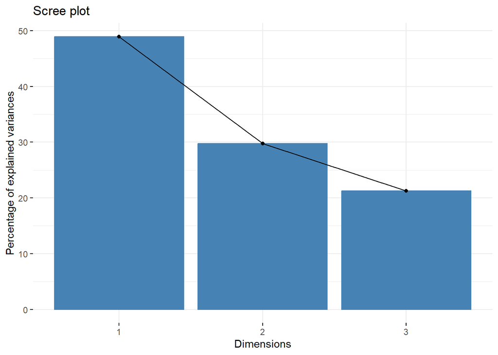

Bazując na powyższym wykresie osypiska oraz powyżej podanych procentach wyjaśnienia zmienności modelu wybieramy wszystkie trzy składowe - próg wynosi 80% wyjaśnionej zmienności.

Przed budową modelu regresji sprawdźmy jeszcze, wkład w wyjaśnienie zmienności poszczególnych zmiennych.

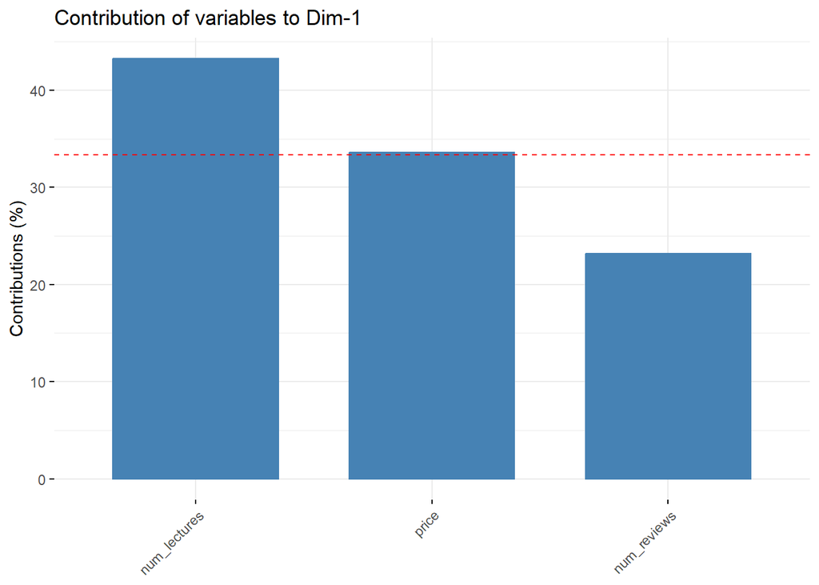

`PC1` najlepiej wyjaśniają zmienne: `num_lectures` oraz `price`

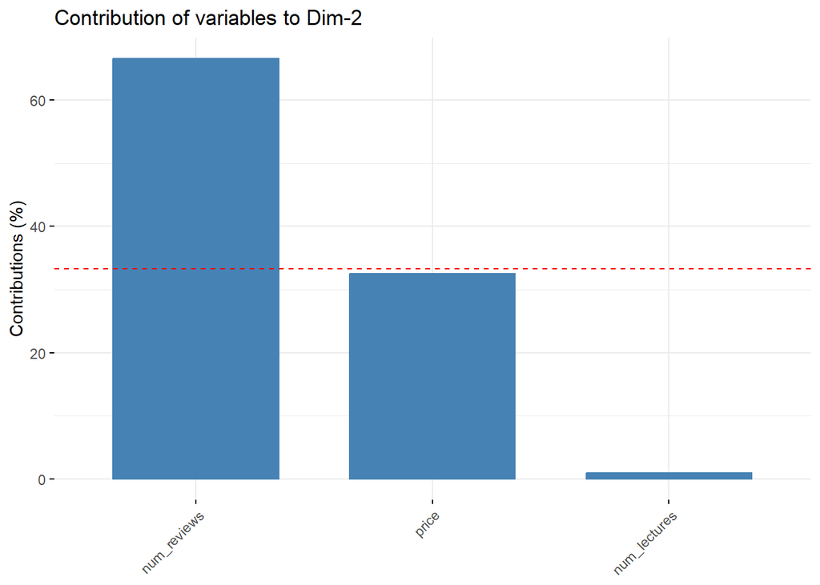

`PC2` najlepiej wyjaśnia zmienna `num_reviews`

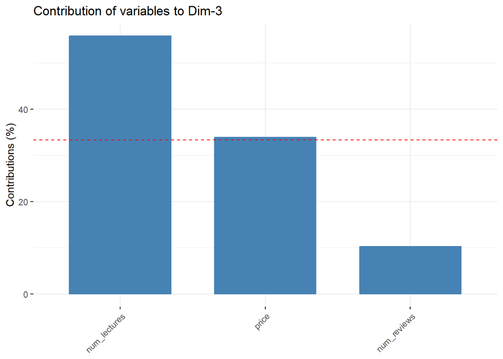

`PC3` wyjaśniają najlepiej zmienne `num_lectures` oraz `price`.

#### Model regresji

Zbudujmy teraz model

```
Call:
lm(formula = df$num_subscribers ~ PC1 + PC2 + PC3)

Residuals:
   Min     1Q Median     3Q    Max
-61863  -2179  -1577   -206 209468

Coefficients:
            Estimate Std. Error t value Pr(>|t|)
(Intercept)  3190.59     118.83   26.85   <2e-16 ***
PC1          2886.22      98.07   29.43   <2e-16 ***
PC2          5183.55     125.81   41.20   <2e-16 ***
PC3         -1771.18     148.68  -11.91   <2e-16 ***
---
Signif. codes:  0 '***' 0.001 '**' 0.01 '*' 0.05 '.' 0.1 ' ' 1

Residual standard error: 7201 on 3668 degrees of freedom
Multiple R-squared:  0.4245,    Adjusted R-squared:  0.424
F-statistic: 901.9 on 3 and 3668 DF,  p-value: < 2.2e-16
```

```
[1] 7196.7610267    0.4245157 2823.8107177
```

Na podstawie otrzymanej statystyki testu F której p.value <0.05 możemy stwierdzić, że model jest istotny statystycznie.

Wszystkie współczynniki są statystycznie istotne.

Jednak bazując na ocenach modelu

- RMSE - 7196.76
- R.squared - 0.42
- MAE - 2823.81

Możemy zauważyć, że model jest jeszcze gorszy od poprzedniego.

Na to miał pewnie wpływ brak zmiennych jakościowych. Dostarczały one wiele istotnych informacji do modelu. W szczególności brak zmiennej `is_paid` mógł mieć duży wpływ na zmienną `price`. Bez informacji o darmowości kursu `price` jest zaburzana przez ogromną różnice w popularności płatnych i bezpłatnych kursów. Dodanie zmiennej `num_lectures` nie wynagrodziło tych braków.

### Drzewo decyzyjne

Drzewo decyzyjne to narzędzie stosowane w uczeniu maszynowym do modelowania przewidywań i decyzji. Składa się z węzłów reprezentujących pytania lub decyzje, oraz z gałęzi, które prowadzą do odpowiedzi lub kolejnych pytań. Proces ten kończy się na liściach drzewa, które przedstawiają ostateczne przewidywania lub decyzje. Drzewa decyzyjne są używane do klasyfikacji lub regresji i charakteryzują się prostotą interpretacji.

Do modelu drzewa decyzyjnego wybieram zmienne **`price`**, **`num_reviews`**, **`num_lectures`**, **`level`**, **`content_duration`**, **`published_timestamp`** oraz **`subject`**.

Do predykcji podzieliliśmy zbiór danych na zbiór treningowy i testowy w proporcjach 80:20

Użyliśmy set.seed aby mieć powtarzalność wyników i wniosków

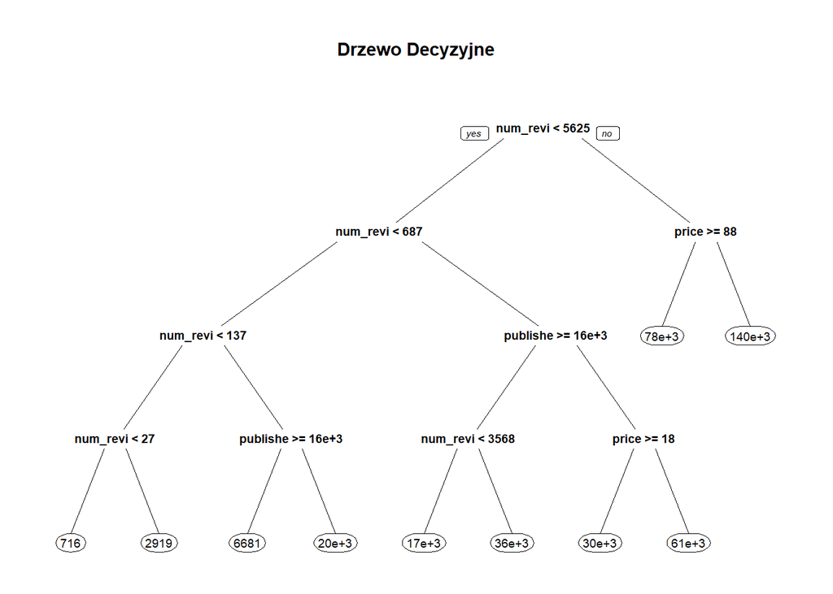

| RMSE | Rsquared | MAE |
| --- | --- | --- |
| 5115.595 | 0.5640084 | 2179.52 |

### Las losowy

Las losowy, znany również jako Random Forest, to zaawansowana metoda uczenia maszynowego oparta na agregacji wielu drzew decyzyjnych do generowania bardziej precyzyjnych i stabilnych prognoz. Jest to przykład tzw. techniki “ensemble learning”, gdzie wielokrotne modele (w tym przypadku drzewa decyzyjne) są łączone w celu uzyskania lepszych wyników niż każdy z modeli oddzielnie.

1. **Tworzenie wielu drzew decyzyjnych**: Las losowy składa się z dużej liczby drzew decyzyjnych. Każde drzewo jest trenowane na nieco innej próbce danych, często wybieranej metodą bootstrap (losowy wybór z powtórzeniami).
2. **Różnorodność**: Każde drzewo w lesie losowym jest budowane z wykorzystaniem losowego podzbioru cech, co zwiększa różnorodność w modelu i pomaga w redukcji nadmiernego dopasowania (ang. overfitting).
3. **Wysoka dokładność i stabilność**: Dzięki agregacji wyników z wielu modeli, lasy losowe często osiągają wysoką dokładność i są odporne na nadmierne dopasowanie, co czyni je skutecznymi w szerokim zakresie zastosowań.
4. **Uniwersalność**: Lasy losowe mogą być stosowane zarówno do problemów klasyfikacji, jak i regresji, a także do innych zadań, takich jak klasyfikacja wieloklasowa, detekcja anomalii i inne.

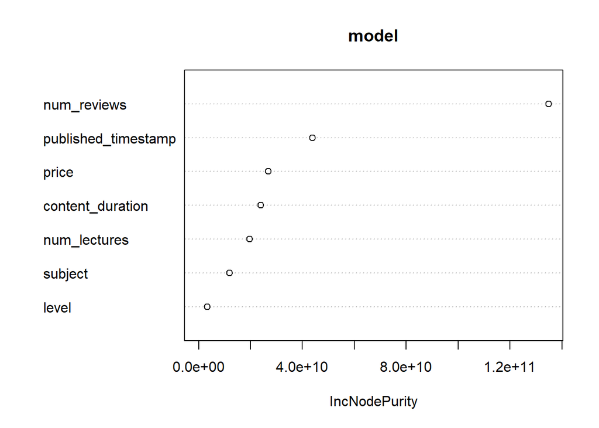

| RMSE | Rsquared | MAE |
| --- | --- | --- |
| 4081.392 | 0.6960786 | 1848.716 |

### Porównanie modeli

| Model | RMSE | Rsquared | MAE |
| --- | --- | --- | --- |
| Drzewo decyzyjne | 5115.595 | 0.5640084 | 2179.520 |
| Las losowy | 4081.392 | 0.6960786 | 1848.716 |
| Regresja liniowa | 6502.528 | 0.5301884 | 2624.015 |
| PCA | 7196.761 | 0.4245157 | 2823.811 |

Podsumowując, **Las Losowy** wydaje się być najlepszym modelem w tym zestawieniu, oferując najbardziej dokładne i spójne prognozy. **Drzewo Decyzyjne** i **Regresja Liniowa** prezentują średnią wydajność, podczas gdy model oparty na **PCA** wydaje się być najmniej skuteczny w tych konkretnych warunkach.

## Podsumowanie

Z czasem platforma Udemy stale się rozwija zyskując co roku znaczącą liczbę kursów.

Analiza rynku kursów online na platformie Udemy ukazała szeroki wachlarz cenowy - od darmowych po kursy kosztujące do 200 USD, z medianą subskrypcji na poziomie 911,5.

Porównanie modeli prognostycznych dla liczby subskrybentów wykazało, że model Lasu Losowego ma najlepsze wskaźniki wydajności (najniższy RMSE i najwyższy R^2), co czyni go najlepszym wyborem wśród rozważanych opcji. Drzewo Decyzyjne i Regresja Liniowa mają średnie wskaźniki, natomiast PCA pokazało się jako najmniej skuteczny model.

Wnioski z projektu wskazują na dynamiczny i różnorodny rynek kursów online, z pewnymi kursami osiągającymi znaczącą popularność, podczas gdy inne pozostają mniej znane.